# Part I - (PISA 2012 Dataset Analysis)

## Preliminary Wrangling

```python
# import all packages and set plots to be embedded inline
import numpy as np
import pandas as pd
import matplotlib.pyplot as plt
import seaborn as sb

%matplotlib inline
```

```python
pisa = pd.read_csv('pisa2012.csv', encoding='latin-1')
pisa.head()
```

|  | Unnamed: 0 | CNT | SUBNATIO | STRATUM | OECD | NC | SCHOOLID | STIDSTD | ST01Q01 | ST02Q01 | ... | W_FSTR75 | W_FSTR76 | W_FSTR77 | W_FSTR78 | W_FSTR79 | W_FSTR80 | WVARSTRR | VAR_UNIT | SENWGT_STU | VER_STU |
| --- | --- | --- | --- | --- | --- | --- | --- | --- | --- | --- | --- | --- | --- | --- | --- | --- | --- | --- | --- | --- | --- |
| 0 | 1 | Albania | 80000 | ALB0006 | Non-OECD | Albania | 1 | 1 | 10 | 1.0 | ... | 13.7954 | 13.9235 | 13.1249 | 13.1249 | 4.3389 | 13.0829 | 19 | 1 | 0.2098 | 22NOV13 |
| 1 | 2 | Albania | 80000 | ALB0006 | Non-OECD | Albania | 1 | 2 | 10 | 1.0 | ... | 13.7954 | 13.9235 | 13.1249 | 13.1249 | 4.3389 | 13.0829 | 19 | 1 | 0.2098 | 22NOV13 |
| 2 | 3 | Albania | 80000 | ALB0006 | Non-OECD | Albania | 1 | 3 | 9 | 1.0 | ... | 12.7307 | 12.7307 | 12.7307 | 12.7307 | 4.2436 | 12.7307 | 19 | 1 | 0.1999 | 22NOV13 |
| 3 | 4 | Albania | 80000 | ALB0006 | Non-OECD | Albania | 1 | 4 | 9 | 1.0 | ... | 12.7307 | 12.7307 | 12.7307 | 12.7307 | 4.2436 | 12.7307 | 19 | 1 | 0.1999 | 22NOV13 |
| 4 | 5 | Albania | 80000 | ALB0006 | Non-OECD | Albania | 1 | 5 | 9 | 1.0 | ... | 12.7307 | 12.7307 | 12.7307 | 12.7307 | 4.2436 | 12.7307 | 19 | 1 | 0.1999 | 22NOV13 |

5 rows × 636 columns

```python
#Check duplication
pisa.duplicated().sum()
```

```
0
```

```python
#Check number of rows X columns
pisa.shape
```

```
(485490, 636)
```

```python
# Columns that choose for my analysis
pisa_df = pisa[['STIDSTD',
'CNT',
'ST03Q02',
'ST04Q01',
'ST11Q01',
'ST11Q02',
'ST11Q03',
'ST11Q04',
'ST11Q05',
'ST11Q06',
'ST15Q01',
'ST19Q01',
'ST25Q01',
'HISCED',
'PV1MATH',
'PV1READ',
'PV1SCIE',
'PV2MATH',
'PV2READ',
'PV2SCIE',
'PV3MATH',
'PV3READ',
'PV3SCIE',
'PV4MATH',
'PV4READ',
'PV4SCIE',
'PV5MATH',
'PV5READ',
'PV5SCIE',
'ST57Q01',
'ST57Q02',
'ST57Q03',
'ST57Q04',
'ST57Q05',
'ST57Q06'
]]
```

```python
pisa_df.head()
```

|  | STIDSTD | CNT | ST03Q02 | ST04Q01 | ST11Q01 | ST11Q02 | ST11Q03 | ST11Q04 | ST11Q05 | ST11Q06 | ... | PV4SCIE | PV5MATH | PV5READ | PV5SCIE | ST57Q01 | ST57Q02 | ST57Q03 | ST57Q04 | ST57Q05 | ST57Q06 |
| --- | --- | --- | --- | --- | --- | --- | --- | --- | --- | --- | --- | --- | --- | --- | --- | --- | --- | --- | --- | --- | --- |
| 0 | 1 | Albania | 1996 | Female | Yes | Yes | Yes | Yes | NaN | NaN | ... | 367.8105 | 381.9209 | 218.5981 | 392.9877 | NaN | NaN | NaN | NaN | NaN | NaN |
| 1 | 2 | Albania | 1996 | Female | Yes | Yes | NaN | Yes | NaN | NaN | ... | 443.6218 | 476.0165 | 396.7618 | 454.8116 | NaN | NaN | 6.0 | 0.0 | 0.0 | 2.0 |
| 2 | 3 | Albania | 1996 | Female | Yes | Yes | No | Yes | No | No | ... | 512.7191 | 533.2684 | 401.2100 | 499.6643 | NaN | 6.0 | 6.0 | 7.0 | 2.0 | 3.0 |
| 3 | 4 | Albania | 1996 | Female | Yes | Yes | No | Yes | No | No | ... | 474.1141 | 454.2842 | 471.9036 | 426.5573 | 10.0 | 2.0 | 2.0 | 0.0 | 0.0 | 3.0 |
| 4 | 5 | Albania | 1996 | Female | Yes | Yes | Yes | NaN | NaN | NaN | ... | 403.5248 | 395.1628 | 260.1405 | 422.1746 | NaN | NaN | NaN | NaN | NaN | NaN |

5 rows × 35 columns

```python
#Rename columns regard dataset dictonary
pisa_df.rename({'STIDSTD':'Student_Id',
'ST04Q01':'Gender',
'ST03Q02':'Birth_Year',
'CNT':'Country_code',
'ST11Q01':'have_Mother',
'ST11Q02':'have_Father',
'ST11Q03':'have_Brothers',
'ST11Q04':'have_Sisters',
'ST11Q05':'have_Grandparents',
'ST11Q06':'have_Any_Part_family',
'ST15Q01':'Mother_job',
'ST19Q01':'Father_job',
'HISCED' :'Parents_Highest_Education',
'ST25Q01':'Language_at_home',
'PV1MATH':'Math_Score1',
'PV1READ':'Reading_Score1',
'PV1SCIE':'Science_Score1',
'PV2MATH':'Math_Score2',
'PV2READ':'Reading_Score2',
'PV2SCIE':'Science_Score2',
'PV3MATH':'Math_Score3',
'PV3READ':'Reading_Score3',
'PV3SCIE':'Science_Score3',
'PV4MATH':'Math_Score4',
'PV4READ':'Reading_Score4',
'PV4SCIE':'Science_Score4',
'PV5MATH':'Math_Score5',
'PV5READ':'Reading_Score5',
'PV5SCIE':'Science_Score5',
'ST57Q01':'Homework_time',
'ST57Q02':'Guided_HomeWork_Time',
'ST57Q03':'Personal_Tutor_Time',
'ST57Q04':'Commercial_Company_time',
'ST57Q05':'Study_With_parent_time',
'ST57Q06':'Study_On_Computer_Time'
}, axis='columns', inplace=True)
```

```python
pisa_df.shape
```

```
(485490, 35)
```

```python
# Test rename columns and see null values and data type
pisa_df.info()
```

```
<class 'pandas.core.frame.DataFrame'>
RangeIndex: 485490 entries, 0 to 485489
Data columns (total 35 columns):
 #   Column                     Non-Null Count   Dtype
---  ------                     --------------   -----
 0   Student_Id                 485490 non-null  int64
 1   Country_code               485490 non-null  object
 2   Birth_Year                 485490 non-null  int64
 3   Gender                     485490 non-null  object
 4   have_Mother                460559 non-null  object
 5   have_Father                441036 non-null  object
 6   have_Brothers              400076 non-null  object
 7   have_Sisters               390768 non-null  object
 8   have_Grandparents          348180 non-null  object
 9   have_Any_Part_family       337638 non-null  object
```

[output cut: 27 more lines]

##### - Put the same contry togather

```python
#Check unique value
pisa_df['Country_code'].unique()
```

```
array(['Albania', 'United Arab Emirates', 'Argentina', 'Australia',
       'Austria', 'Belgium', 'Bulgaria', 'Brazil', 'Canada',
       'Switzerland', 'Chile', 'Colombia', 'Costa Rica', 'Czech Republic',
       'Germany', 'Denmark', 'Spain', 'Estonia', 'Finland', 'France',
       'United Kingdom', 'Greece', 'Hong Kong-China', 'Croatia',
       'Hungary', 'Indonesia', 'Ireland', 'Iceland', 'Israel', 'Italy',
       'Jordan', 'Japan', 'Kazakhstan', 'Korea', 'Liechtenstein',
       'Lithuania', 'Luxembourg', 'Latvia', 'Macao-China', 'Mexico',
       'Montenegro', 'Malaysia', 'Netherlands', 'Norway', 'New Zealand',
       'Peru', 'Poland', 'Portugal', 'Qatar', 'China-Shanghai',
       'Perm(Russian Federation)', 'Florida (USA)', 'Connecticut (USA)',
       'Massachusetts (USA)', 'Romania', 'Russian Federation',
       'Singapore', 'Serbia', 'Slovak Republic', 'Slovenia', 'Sweden',
       'Chinese Taipei', 'Thailand', 'Tunisia', 'Turkey', 'Uruguay',
       'United States of America', 'Vietnam'], dtype=object)
```

```python
#Function for put contry states and diffrent name of contry in one value
def changeCountry(df):

    if df['Country_code'] in ['Connecticut (USA)', 'Florida (USA)', 'Massachusetts (USA)', 'United States of America']:
        return 'USA'
    elif df['Country_code'] in ['Russian Federation', 'Perm(Russian Federation)']:
        return'Russia'
    elif df['Country_code'] in ['United Kingdom']:
        return 'UK'
    elif df['Country_code'] in ['United Arab Emirates']:
        return 'UAE'
    elif df['Country_code'] in ['China-Shanghai', 'Macao-China', 'Macao']:
        return 'China'
    elif df['Country_code'] in ['Hong Kong-China']:
        return 'Hong Kong'
    elif df['Country_code'] in ['Czechia', 'Czech Republic']:
        return 'Czech'
    elif df['Country_code'] in ['Chinese Taipei']:
        return 'Taiwan'
    else:
        return df['Country_code']
```

```python
pisa_df['Country'] = pisa_df.apply(lambda pisa_df : changeCountry(pisa_df), axis=1)
```

```python
pisa_df['Country'].unique()
```

```
array(['Albania', 'UAE', 'Argentina', 'Australia', 'Austria', 'Belgium',
       'Bulgaria', 'Brazil', 'Canada', 'Switzerland', 'Chile', 'Colombia',
       'Costa Rica', 'Czech', 'Germany', 'Denmark', 'Spain', 'Estonia',
       'Finland', 'France', 'UK', 'Greece', 'Hong Kong', 'Croatia',
       'Hungary', 'Indonesia', 'Ireland', 'Iceland', 'Israel', 'Italy',
       'Jordan', 'Japan', 'Kazakhstan', 'Korea', 'Liechtenstein',
       'Lithuania', 'Luxembourg', 'Latvia', 'China', 'Mexico',
       'Montenegro', 'Malaysia', 'Netherlands', 'Norway', 'New Zealand',
       'Peru', 'Poland', 'Portugal', 'Qatar', 'Russia', 'USA', 'Romania',
       'Singapore', 'Serbia', 'Slovak Republic', 'Slovenia', 'Sweden',
       'Taiwan', 'Thailand', 'Tunisia', 'Turkey', 'Uruguay', 'Vietnam'],
      dtype=object)
```

```python
pisa_df.drop(['Country_code'], axis=1, inplace=True)
```

##### - Students life with family

```python
# Transform 6 columns to one column (with_Family)

def transformColumns(df):
    if df['have_Mother'] == 'Yes' or df['have_Father'] == 'Yes' or df['have_Brothers'] == 'Yes' or df['have_Sisters'] == 'Yes' or df['have_Grandparents'] == 'Yes' or df['have_Any_Part_family'] == 'Yes':
            return True
    else:
        return False

pisa_df['with_Family'] = pisa_df.apply(lambda pisa_df: transformColumns(pisa_df), axis=1)

pisa_df.drop(['have_Mother', 'have_Father', 'have_Brothers', 'have_Sisters', 'have_Grandparents', 'have_Any_Part_family'], axis=1, inplace=True)

pisa_df.head()
```

|  | Student_Id | Birth_Year | Gender | Mother_job | Father_job | Language_at_home | Parents_Highest_Education | Math_Score1 | Reading_Score1 | Science_Score1 | ... | Reading_Score5 | Science_Score5 | Homework_time | Guided_HomeWork_Time | Personal_Tutor_Time | Commercial_Company_time | Study_With_parent_time | Study_On_Computer_Time | Country | with_Family |
| --- | --- | --- | --- | --- | --- | --- | --- | --- | --- | --- | --- | --- | --- | --- | --- | --- | --- | --- | --- | --- | --- |
| 0 | 1 | 1996 | Female | Other (e.g. home duties, retired) | Working part-time <for pay> | Language of the test | ISCED 3A, ISCED 4 | 406.8469 | 249.5762 | 341.7009 | ... | 218.5981 | 392.9877 | NaN | NaN | NaN | NaN | NaN | NaN | Albania | True |
| 1 | 2 | 1996 | Female | Working full-time <for pay> | Working full-time <for pay> | Language of the test | ISCED 5A, 6 | 486.1427 | 406.2936 | 548.9929 | ... | 396.7618 | 454.8116 | NaN | NaN | 6.0 | 0.0 | 0.0 | 2.0 | Albania | True |
| 2 | 3 | 1996 | Female | Working full-time <for pay> | Working full-time <for pay> | Language of the test | ISCED 5A, 6 | 533.2684 | 401.2100 | 499.6643 | ... | 401.2100 | 499.6643 | NaN | 6.0 | 6.0 | 7.0 | 2.0 | 3.0 | Albania | True |
| 3 | 4 | 1996 | Female | Working full-time <for pay> | Working full-time <for pay> | Language of the test | ISCED 5A, 6 | 412.2215 | 547.3630 | 438.6796 | ... | 471.9036 | 426.5573 | 10.0 | 2.0 | 2.0 | 0.0 | 0.0 | 3.0 | Albania | True |
| 4 | 5 | 1996 | Female | Working part-time <for pay> | Working part-time <for pay> | Language of the test | ISCED 3A, ISCED 4 | 381.9209 | 311.7707 | 361.5628 | ... | 260.1405 | 422.1746 | NaN | NaN | NaN | NaN | NaN | NaN | Albania | True |

5 rows × 30 columns

##### - Change null values for (Mother_job , Father_job) columns to (Other (e.g. home duties, retired) )

```python
# Check null values of mother_job
pisa_df['Mother_job'].isnull().sum()
```

```
17739
```

```python
# Check unique values of mother_job
pisa_df['Mother_job'].unique()
```

```
array(['Other (e.g. home duties, retired) ',
       'Working full-time <for pay> ', 'Working part-time <for pay>',
       'Not working, but looking for a job ', nan], dtype=object)
```

```python
# Replace null values with others for (Mother_job)
pisa_df['Mother_job'].replace(np.nan, 'Other (e.g. home duties, retired) ', inplace = True)
```

```python
# test null values of Mother_job
pisa_df['Mother_job'].isnull().sum()
```

```
0
```

```python
# count values of Mother_job
pisa_df['Mother_job'].value_counts()
```

```
Working full-time <for pay>            219095
Other (e.g. home duties, retired)      156580
Working part-time <for pay>             78237
Not working, but looking for a job      31578
Name: Mother_job, dtype: int64
```

```python
# Check null values of Father_job
pisa_df['Father_job'].isnull().sum()
```

```
34080
```

```python
# Check unique values of Father_job
pisa_df['Father_job'].unique()
```

```
array(['Working part-time <for pay>', 'Working full-time <for pay> ',
       'Not working, but looking for a job',
       'Other (e.g. home duties, retired) ', nan], dtype=object)
```

```python
# Replace null values with others for (Father_job)
pisa_df['Father_job'].replace(np.nan, 'Other (e.g. home duties, retired) ', inplace = True)
```

```python
# test null values of Father_job
pisa_df['Father_job'].isnull().sum()
```

```
0
```

```python
# count values of Father_job
pisa_df['Father_job'].value_counts()
```

```
Working full-time <for pay>           339697
Other (e.g. home duties, retired)      74668
Working part-time <for pay>            49503
Not working, but looking for a job     21622
Name: Father_job, dtype: int64
```

```python
pisa_df.info()
```

```
<class 'pandas.core.frame.DataFrame'>
RangeIndex: 485490 entries, 0 to 485489
Data columns (total 30 columns):
 #   Column                     Non-Null Count   Dtype
---  ------                     --------------   -----
 0   Student_Id                 485490 non-null  int64
 1   Birth_Year                 485490 non-null  int64
 2   Gender                     485490 non-null  object
 3   Mother_job                 485490 non-null  object
 4   Father_job                 485490 non-null  object
 5   Language_at_home           465496 non-null  object
 6   Parents_Highest_Education  473091 non-null  object
 7   Math_Score1                485490 non-null  float64
 8   Reading_Score1             485490 non-null  float64
 9   Science_Score1             485490 non-null  float64
```

[output cut: 22 more lines]

##### - Change null values of (Language_at_home) column to Other language.

```python
#Check unique value
pisa_df['Language_at_home'].unique()
```

```
array(['Language of the test', nan, 'Other language'], dtype=object)
```

```python
#Replace null value with 'Other language'
pisa_df['Language_at_home'].replace(np.nan, 'Other language', inplace = True)
```

```python
#Count values of Language_at_home
pisa_df['Language_at_home'].value_counts()
```

```
Language of the test    408141
Other language           77349
Name: Language_at_home, dtype: int64
```

```python
pisa_df.info()
```

```
<class 'pandas.core.frame.DataFrame'>
RangeIndex: 485490 entries, 0 to 485489
Data columns (total 30 columns):
 #   Column                     Non-Null Count   Dtype
---  ------                     --------------   -----
 0   Student_Id                 485490 non-null  int64
 1   Birth_Year                 485490 non-null  int64
 2   Gender                     485490 non-null  object
 3   Mother_job                 485490 non-null  object
 4   Father_job                 485490 non-null  object
 5   Language_at_home           485490 non-null  object
 6   Parents_Highest_Education  473091 non-null  object
 7   Math_Score1                485490 non-null  float64
 8   Reading_Score1             485490 non-null  float64
 9   Science_Score1             485490 non-null  float64
```

[output cut: 22 more lines]

##### - Change null values to None in (Parents_Highest_Education) column

```python
#Check Education Level
pisa_df['Parents_Highest_Education'].unique()
```

```
array(['ISCED 3A, ISCED 4', 'ISCED 5A, 6', 'ISCED 3B, C', 'ISCED 2',
       'ISCED 5B', 'None', 'ISCED 1', nan], dtype=object)
```

```python
# Replace nan values to None
pisa_df['Parents_Highest_Education'].replace(np.nan, 'None', inplace = True)
```

```python
pisa_df['Parents_Highest_Education'].unique()
```

```
array(['ISCED 3A, ISCED 4', 'ISCED 5A, 6', 'ISCED 3B, C', 'ISCED 2',
       'ISCED 5B', 'None', 'ISCED 1'], dtype=object)
```

```python
#Function helps to replace symbles of level education

def levelOfEducation(df):
    if df['Parents_Highest_Education'] in ['ISCED 1']:
        return 'Primary education'
    elif df['Parents_Highest_Education'] in ['ISCED 2']:
        return  'Lower secondary education'
    elif df['Parents_Highest_Education'] in ['ISCED 3A' , 'ISCED 3B, C']:
        return 'Upper secondary education'
    elif df['Parents_Highest_Education'] in ['ISCED 4']:
        return 'Post-secondary non-tertiary education'
    elif df['Parents_Highest_Education'] in ['ISCED 5B']:
        return 'Short-cycle tertiary or Bachelor’s'
    elif df['Parents_Highest_Education'] in ['ISCED 5A, 6']:
        return ' Master’s, or Doctoral'
    else:
        return 'Early childhood education'
```

```python
# Apply function to dataset
pisa_df['Parents_Highest_Education'] = pisa_df.apply(lambda pisa_df : levelOfEducation(pisa_df), axis=1)
```

```python
pisa_df.info()
```

```
<class 'pandas.core.frame.DataFrame'>
RangeIndex: 485490 entries, 0 to 485489
Data columns (total 30 columns):
 #   Column                     Non-Null Count   Dtype
---  ------                     --------------   -----
 0   Student_Id                 485490 non-null  int64
 1   Birth_Year                 485490 non-null  int64
 2   Gender                     485490 non-null  object
 3   Mother_job                 485490 non-null  object
 4   Father_job                 485490 non-null  object
 5   Language_at_home           485490 non-null  object
 6   Parents_Highest_Education  485490 non-null  object
 7   Math_Score1                485490 non-null  float64
 8   Reading_Score1             485490 non-null  float64
 9   Science_Score1             485490 non-null  float64
```

[output cut: 22 more lines]

```python
#Check unique value
pisa_df['Parents_Highest_Education'].unique()
```

```
array(['Early childhood education', ' Master’s, or Doctoral',
       'Upper secondary education', 'Lower secondary education',
       'Short-cycle tertiary or Bachelor’s', 'Primary education'],
      dtype=object)
```

##### - Calculate Average Score of Math, Reading, and Science

```python
# Avg of scores of topics
pisa_df['Math Score'] = (pisa_df['Math_Score1'] + pisa_df['Math_Score2'] + pisa_df['Math_Score3'] + pisa_df['Math_Score4'] + pisa_df['Math_Score5']) / 5
pisa_df['Reading Score'] = (pisa_df['Reading_Score1'] + pisa_df['Reading_Score2'] + pisa_df['Reading_Score3'] + pisa_df['Reading_Score4'] + pisa_df['Reading_Score5']) / 5
pisa_df['Science Score'] = (pisa_df['Science_Score1'] + pisa_df['Science_Score2'] + pisa_df['Science_Score3'] + pisa_df['Science_Score4'] + pisa_df['Science_Score5']) / 5
```

```python
# drop columns of topics score that not use any more
pisa_df.drop(['Math_Score1', 'Math_Score2', 'Math_Score3', 'Math_Score4', 'Math_Score5', 'Reading_Score1',
             'Reading_Score2','Reading_Score3','Reading_Score4','Reading_Score5', 'Science_Score1', 'Science_Score2',
             'Science_Score3', 'Science_Score4','Science_Score5'], axis=1, inplace=True)
```

```python
pisa_df.info()
```

```
<class 'pandas.core.frame.DataFrame'>
RangeIndex: 485490 entries, 0 to 485489
Data columns (total 18 columns):
 #   Column                     Non-Null Count   Dtype
---  ------                     --------------   -----
 0   Student_Id                 485490 non-null  int64
 1   Birth_Year                 485490 non-null  int64
 2   Gender                     485490 non-null  object
 3   Mother_job                 485490 non-null  object
 4   Father_job                 485490 non-null  object
 5   Language_at_home           485490 non-null  object
 6   Parents_Highest_Education  485490 non-null  object
 7   Homework_time              301367 non-null  float64
 8   Guided_HomeWork_Time       269808 non-null  float64
 9   Personal_Tutor_Time        283813 non-null  float64
 10  Commercial_Company_time    279657 non-null  float64
 11  Study_With_parent_time     289502 non-null  float64
 12  Study_On_Computer_Time     289428 non-null  float64
 13  Country                    485490 non-null  object
 14  with_Family                485490 non-null  bool
 15  Math Score                 485490 non-null  float64
 16  Reading Score              485490 non-null  float64
 17  Science Score              485490 non-null  float64
dtypes: bool(1), float64(9), int64(2), object(6)
memory usage: 63.4+ MB
```

```python
#Change datatype of some colomns to category
pisa_df = pisa_df.astype({"Gender":'category', "Parents_Highest_Education":'category'})
```

```python
pisa_df.info()
```

```
<class 'pandas.core.frame.DataFrame'>
RangeIndex: 485490 entries, 0 to 485489
Data columns (total 18 columns):
 #   Column                     Non-Null Count   Dtype
---  ------                     --------------   -----
 0   Student_Id                 485490 non-null  int64
 1   Birth_Year                 485490 non-null  int64
 2   Gender                     485490 non-null  category
 3   Mother_job                 485490 non-null  object
 4   Father_job                 485490 non-null  object
 5   Language_at_home           485490 non-null  object
 6   Parents_Highest_Education  485490 non-null  category
 7   Homework_time              301367 non-null  float64
 8   Guided_HomeWork_Time       269808 non-null  float64
 9   Personal_Tutor_Time        283813 non-null  float64
 10  Commercial_Company_time    279657 non-null  float64
 11  Study_With_parent_time     289502 non-null  float64
 12  Study_On_Computer_Time     289428 non-null  float64
 13  Country                    485490 non-null  object
 14  with_Family                485490 non-null  bool
 15  Math Score                 485490 non-null  float64
 16  Reading Score              485490 non-null  float64
 17  Science Score              485490 non-null  float64
dtypes: bool(1), category(2), float64(9), int64(2), object(4)
memory usage: 56.9+ MB
```

```python
pisa_df['Parents_Highest_Education']
```

```
0         Early childhood education
1             Master’s, or Doctoral
2             Master’s, or Doctoral
3             Master’s, or Doctoral
4         Early childhood education
                    ...
485485    Lower secondary education
485486    Lower secondary education
485487    Lower secondary education
485488        Master’s, or Doctoral
485489    Early childhood education
Name: Parents_Highest_Education, Length: 485490, dtype: category
Categories (6, object): [' Master’s, or Doctoral', 'Early childhood education', 'Lower secondary education', 'Primary education', 'Short-cycle tertiary or Bachelor’s', 'Upper secondary education']
```

##### - Time of study time at home

```python
pisa_df['Homework_time'].unique()
```

```
array([nan, 10.,  3.,  8.,  1.,  4.,  5.,  9.,  6.,  7.,  2.,  0., 20.,
       14., 21., 24., 16., 15., 11., 27., 25., 30., 13., 18., 12., 28.,
       26., 23., 19., 17., 22., 29.])
```

```python
# Replace nan value to 0.0
pisa_df['Homework_time'].replace(np.nan, 0.0, inplace = True)
```

```python
pisa_df['Guided_HomeWork_Time'].unique()
```

```
array([nan,  6.,  2.,  3.,  8.,  1.,  0.,  7.,  9.,  4., 10.,  5., 24.,
       14., 30., 12., 15., 17., 18., 11., 22., 25., 13., 21., 16., 20.,
       26., 19., 23., 28., 29., 27.])
```

```python
# Replace nan value to 0.0
pisa_df['Guided_HomeWork_Time'].replace(np.nan, 0.0, inplace = True)
```

```python
pisa_df['Personal_Tutor_Time'].unique()
```

```
array([nan,  6.,  2.,  9.,  0., 10.,  3.,  4.,  8.,  1.,  7.,  5., 14.,
       13., 11., 15., 12., 17., 24., 20., 21., 18., 25., 23., 30., 28.,
       16., 26., 19., 27., 29., 22.])
```

```python
# Replace nan value to 0.0
pisa_df['Personal_Tutor_Time'].replace(np.nan, 0.0, inplace = True)
```

```python
pisa_df['Commercial_Company_time'].unique()
```

```
array([nan,  0.,  7.,  9.,  2.,  3.,  5.,  4.,  6., 10.,  1.,  8., 12.,
       15., 11., 30., 18., 24., 14., 25., 28., 13., 20., 21., 16., 17.,
       29., 19., 23., 22., 27., 26.])
```

```python
# Replace nan value to 0.0
pisa_df['Commercial_Company_time'].replace(np.nan, 0.0, inplace = True)
```

```python
pisa_df['Study_With_parent_time'].unique()
```

```
array([nan,  0.,  2.,  1.,  9.,  3.,  8.,  4.,  6., 10.,  5.,  7., 11.,
       12., 14., 24., 16., 20., 15., 13., 17., 25., 18., 22., 27., 30.,
       23., 29., 21., 28., 19., 26.])
```

```python
# Replace nan value to 0.0
pisa_df['Study_With_parent_time'].replace(np.nan, 0.0, inplace = True)
```

```python
pisa_df['Study_On_Computer_Time'].unique()
```

```
array([nan,  2.,  3.,  0.,  5.,  1.,  8., 14.,  9.,  4.,  6., 15.,  7.,
       10., 24., 20., 16., 17., 18., 11., 12., 30., 13., 25., 19., 21.,
       27., 28., 23., 26., 29., 22.])
```

```python
pisa_df['Study_On_Computer_Time'].replace(np.nan, 0.0, inplace = True)
```

```python
#Calculate total study hours out of school
pisa_df['Total_Study_Hours'] = pisa_df['Homework_time']+pisa_df['Guided_HomeWork_Time']+pisa_df['Personal_Tutor_Time']+pisa_df['Commercial_Company_time']+pisa_df['Study_With_parent_time']+pisa_df['Study_On_Computer_Time']
```

```python
pisa_df['Total_Study_Hours'].sort_values(ascending=False)
```

```
57457     180.0
64079     180.0
26544     180.0
221931    180.0
169492    180.0
          ...
232198      0.0
232203      0.0
232204      0.0
232207      0.0
242745      0.0
Name: Total_Study_Hours, Length: 485490, dtype: float64
```

```python
pisa_df[['Math Score', 'Reading Score', 'Science Score', 'Total_Study_Hours', 'Homework_time', 'Guided_HomeWork_Time', 'Personal_Tutor_Time',
        'Commercial_Company_time', 'Study_With_parent_time','Study_On_Computer_Time']]
```

|  | Math Score | Reading Score | Science Score | Total_Study_Hours | Homework_time | Guided_HomeWork_Time | Personal_Tutor_Time | Commercial_Company_time | Study_With_parent_time | Study_On_Computer_Time |
| --- | --- | --- | --- | --- | --- | --- | --- | --- | --- | --- |
| 0 | 366.18634 | 261.01424 | 371.91348 | 0.0 | 0.0 | 0.0 | 0.0 | 0.0 | 0.0 | 0.0 |
| 1 | 470.56396 | 384.68832 | 478.12382 | 8.0 | 0.0 | 0.0 | 6.0 | 0.0 | 0.0 | 2.0 |
| 2 | 505.53824 | 405.18154 | 486.60946 | 24.0 | 0.0 | 6.0 | 6.0 | 7.0 | 2.0 | 3.0 |
| 3 | 449.45476 | 477.46376 | 453.97240 | 17.0 | 10.0 | 2.0 | 2.0 | 0.0 | 0.0 | 3.0 |
| 4 | 385.50398 | 256.01010 | 367.15778 | 0.0 | 0.0 | 0.0 | 0.0 | 0.0 | 0.0 | 0.0 |
| ... | ... | ... | ... | ... | ... | ... | ... | ... | ... | ... |
| 485485 | 486.22058 | 472.61846 | 536.31110 | 8.0 | 5.0 | 0.0 | 0.0 | 0.0 | 0.0 | 3.0 |
| 485486 | 529.21794 | 487.24356 | 524.37522 | 0.0 | 0.0 | 0.0 | 0.0 | 0.0 | 0.0 | 0.0 |
| 485487 | 486.29850 | 476.25694 | 541.90600 | 0.0 | 0.0 | 0.0 | 0.0 | 0.0 | 0.0 | 0.0 |
| 485488 | 522.90856 | 518.43922 | 526.70646 | 13.0 | 4.0 | 4.0 | 0.0 | 0.0 | 0.0 | 5.0 |
| 485489 | 454.43994 | 488.66354 | 492.95038 | 21.0 | 6.0 | 0.0 | 0.0 | 15.0 | 0.0 | 0.0 |

485490 rows × 10 columns

##### - Save cleaned dataset to csv

```python
#Save cleand data as csv file
pisa_df.to_csv('pisa_clean.csv', index=False)
```

### What is/are the main feature(s) of interest in your dataset?

> I'm interested to know the factors affect on scores of Math, Reading, and Science.

### What features in the dataset do you think will help support your investigation into your feature(s) of interest?

The features that could help me to investigate my interests are:

- 'STIDSTD':'Student_Id'
- 'ST04Q01':'Gender'
- 'ST03Q02':'Birth_Year'
- 'CNT':'Country'
- 'ST11Q01':'have_Mother'
- 'ST11Q02':'have_Father'
- 'ST11Q03':'have_Brothers'
- 'ST11Q04':'have_Sisters'
- 'ST11Q05':'have_Grandparents'
- 'ST11Q06':'have_Any_Part_family'
- 'ST15Q01':'Mother_job'
- 'ST19Q01':'Father_job'
- 'HISCED' :'Parents_Highest_Education'
- 'ST25Q01':'Language_at_home'
- 'PV1MATH':'Math_Score1'
- 'PV1READ':'Reading_Score1'
- 'PV1SCIE':'Science_Score1'
- 'PV2MATH':'Math_Score2'
- 'PV2READ':'Reading_Score2'
- 'PV2SCIE':'Science_Score2'
- 'PV3MATH':'Math_Score3'
- 'PV3READ':'Reading_Score3'
- 'PV3SCIE':'Science_Score3'
- 'PV4MATH':'Math_Score4'
- 'PV4READ':'Reading_Score4'
- 'PV4SCIE':'Science_Score4'
- 'PV5MATH':'Math_Score5'
- 'PV5READ':'Reading_Score5'
- 'PV5SCIE':'Science_Score5'
- 'ST57Q01':'Homework_time'
- 'ST57Q02':'Guided_HomeWork_Time'
- 'ST57Q03':'Personal_Tutor_Time'
- 'ST57Q04':'Commercial_Company_time'
- 'ST57Q05':'Study_With_parent_time'
- 'ST57Q06':'Study_On_Computer_Time'

## Univariate Exploration

> In this section, investigate distributions of individual variables. If you see unusual points or outliers, take a deeper look to clean things up and prepare yourself to look at relationships between variables.

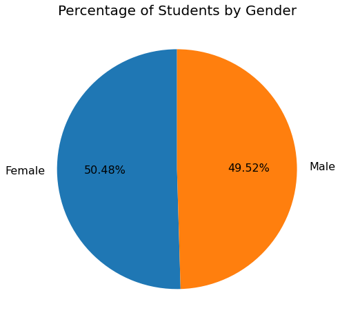

```python
# Investigate Gender

data = pisa_df['Gender'].value_counts()
labels = pisa_df['Gender'].unique()


#create pie chart
plt.figure(figsize=(8,8), )

plt.pie(data, labels = labels,startangle=90, autopct='%1.2f%%', textprops={'fontsize': 16})

plt.title('Percentage of Students by Gender', fontsize=20);
```

- The percentage of Male and female is nearly same which is 50%. So, that it helps us to avoid bise.

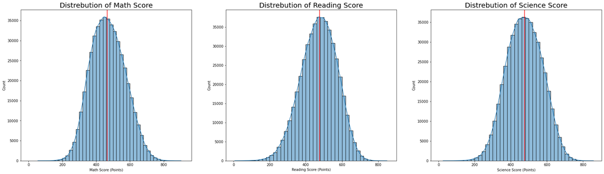

```python
# Distribution of Math, Reading, and Science scores

dataList = ['Math Score', 'Reading Score', 'Science Score']
plt.figure(figsize = [30, 8])

# histogram
c=1
for i in dataList:
    plt.subplot(1, len(dataList), c)
    bins = np.arange(0,pisa_df[i].max()+20,20)
    sb.histplot(pisa_df[i], bins = bins, color=sb.color_palette()[0], kde=True)
    plt.axvline(pisa_df[i].median(),  color='r')
    plt.title('Distrebution of '+ i , fontsize=20)
    plt.xlabel(i + ' (Points)')
    plt.ylabel('Count');
    c=c+1
```

- Scores of Math, Reading and Science are normal distribution. Red line shows the median of score which is nearly 500.

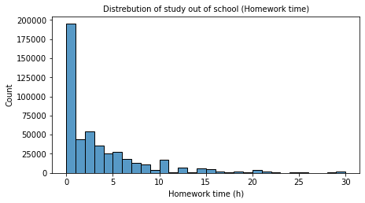

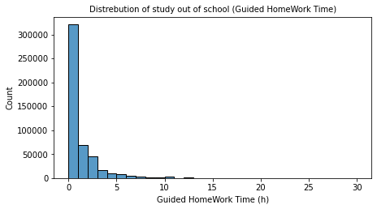

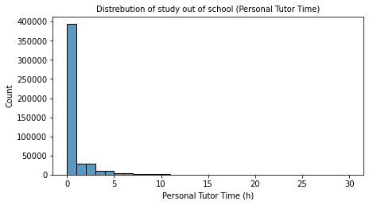

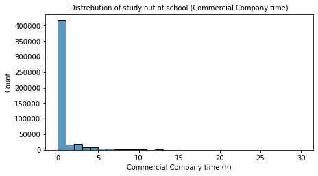

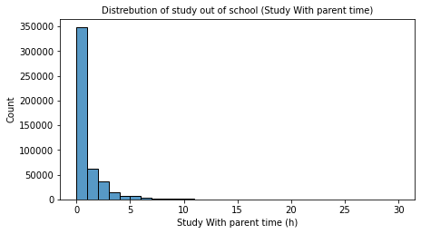

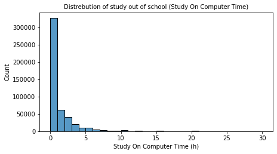

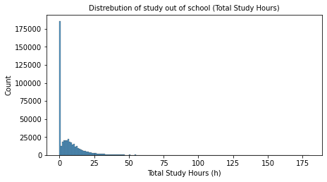

```python
# Distribution of Study time out of school

dataList = ['Homework_time', 'Guided_HomeWork_Time', 'Personal_Tutor_Time', 'Commercial_Company_time',
            'Study_With_parent_time','Study_On_Computer_Time','Total_Study_Hours']


# histogram
c=1
for i in dataList:
    plt.figure(figsize = (7, 30))
    plt.subplot(len(dataList), 1, c, )
    bins=np.arange(0,pisa_df[i].max()+1, 1)
    sb.histplot(pisa_df[i], bins=bins, color=sb.color_palette()[0], kde=False)
    plt.autoscale()
    plt.title('Distrebution of study out of school ('+ i.replace('_',' ') +')' , fontsize=10)
    plt.xlabel(i.replace('_',' ') +' (h)')
    plt.ylabel('Count');
    c=c+1
```

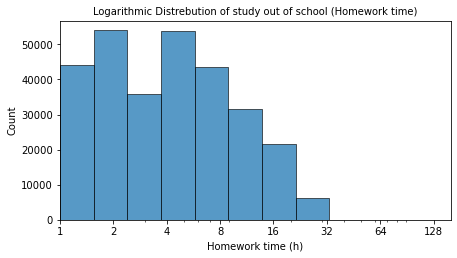

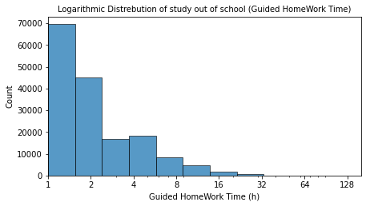

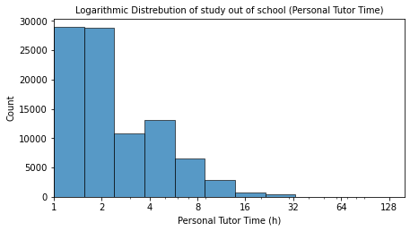

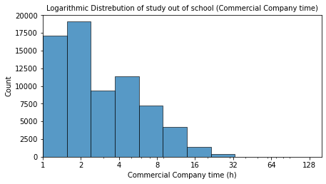

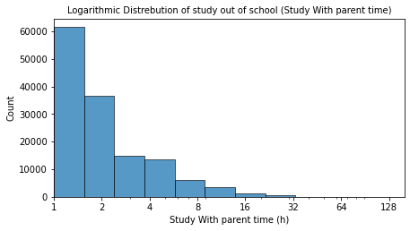

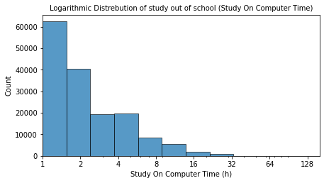

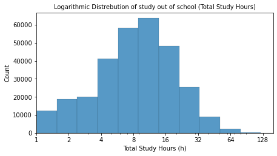

```python
# Logarithmic distribution of Study time out of school

dataList = ['Homework_time', 'Guided_HomeWork_Time', 'Personal_Tutor_Time', 'Commercial_Company_time',
            'Study_With_parent_time','Study_On_Computer_Time','Total_Study_Hours']


# histogram
c=1
for i in dataList:
    plt.figure(figsize = (7, 30))
    plt.subplot(len(dataList), 1, c, )
    log_binsize = 0.19
    bins = 10 ** np.arange(0, np.log10(pisa_df[i].max())+log_binsize, log_binsize)
    ticks = [0, 1, 2, 4, 8, 16, 32, 64, 128, 180]
    labels = [f'{x}' for x in ticks]

    sb.histplot(pisa_df[i], bins=bins, color=sb.color_palette()[0], kde=False)
    plt.xscale('log')
    plt.xticks(ticks, labels)
    plt.xlim([1, 160])
    plt.title('Logarithmic Distrebution of study out of school ('+ i.replace('_',' ') +')' , fontsize=10)
    plt.xlabel(i.replace('_',' ') + ' (h)')
    plt.ylabel('Count');
    c=c+1
```

- The distrbution of each part of study out of school is skewed right. However, we calculate the total of study out of school. Then, we made distrpution plot which is skewed right. When we use logarithmic scale, we got normal distribution for total study out of school.

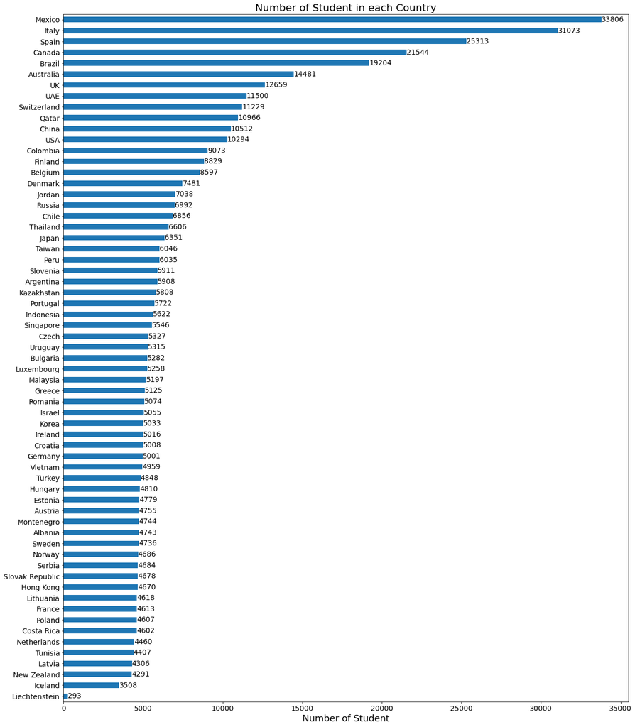

```python
#Plot for number of student from each country
data = pisa_df['Country'].value_counts().sort_values()

plt.figure(figsize = [20, 25])

data.plot(kind='barh', fontsize=14, color=sb.color_palette()[0])

for i, v in enumerate(data):
    plt.text(v , i , str(v), color='black',  verticalalignment='center', fontsize=14)

plt.title('Number of Student in each Country',fontsize=20)
plt.xlabel('Number of Student', fontsize=18);
```

- The bar chart shows the number of student in each contry. Mexico has highest number of student which is 33806. However, Liechtenstein has 293 students who participate in survey.

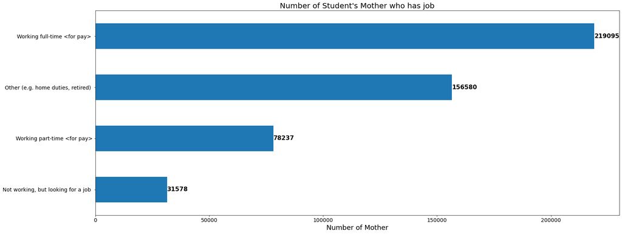

```python
#Number of mothers who has job

data = pisa_df['Mother_job'].value_counts().sort_values()

plt.figure(figsize = [25, 10])

data.plot(kind='barh', fontsize=14, color=sb.color_palette()[0])

for i, v in enumerate(data):
    plt.text(v , i , str(v), color='black', fontweight='bold',  verticalalignment='center', fontsize=16)

plt.title("Number of Student's Mother who has job",fontsize=20)
plt.xlabel('Number of Mother', fontsize=18);
```

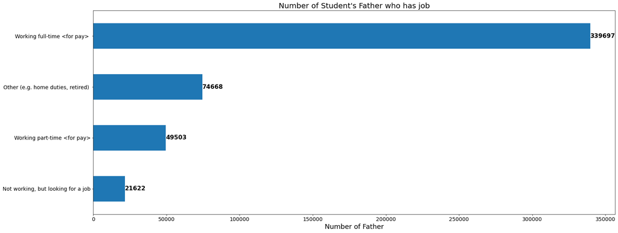

```python
#Number of fathers who has job
data = pisa_df['Father_job'].value_counts().sort_values()

plt.figure(figsize = [25, 10])

data.plot(kind='barh', fontsize=14, color=sb.color_palette()[0])

for i, v in enumerate(data):
    plt.text(v , i , str(v), color='black', fontweight='bold',  verticalalignment='center', fontsize=16)

plt.title("Number of Student's Father who has job",fontsize=20)
plt.xlabel('Number of Father', fontsize=18);
```

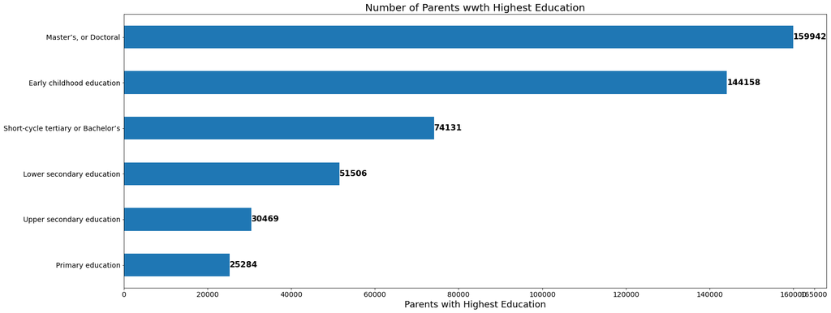

```python
#Number of parent in each education level
data = pisa_df['Parents_Highest_Education'].value_counts().sort_values()

plt.figure(figsize = [25, 10])

data.plot(kind='barh', fontsize=14, color=sb.color_palette()[0])

for i, v in enumerate(data):
    plt.text(v , i , str(v), color='black', fontweight='bold',  verticalalignment='center', fontsize=16)
xticks = [0,20000, 40000, 60000,80000,100000,120000, 140000, 160000, 165000]
plt.xticks(xticks)
plt.title("Number of Parents wwth Highest Education",fontsize=20)
plt.xlabel('Parents with Highest Education', fontsize=18);
```

### Discuss the distribution(s) of your variable(s) of interest. Were there any unusual points? Did you need to perform any transformations?

> The distribution of scores in Math, Reading, and Science is normal distribution. However, the distribution of time study out-of-school is skewed right but we scale as logarithmic to be normal distribution.

### Of the features you investigated, were there any unusual distributions? Did you perform any operations on the data to tidy, adjust, or change the form of the data? If so, why did you do this?

> As can be seen, the features of the time of study out of school are skewed right. So, we decided to sum all time of study out of school to get the total study out-of-school time. Then, we used a logarithmic scale to total study out-of-school time to get normal distribution.

## Bivariate Exploration

> In this section, investigate relationships between pairs of variables in your data. Make sure the variables that you cover here have been introduced in some fashion in the previous section (univariate exploration).

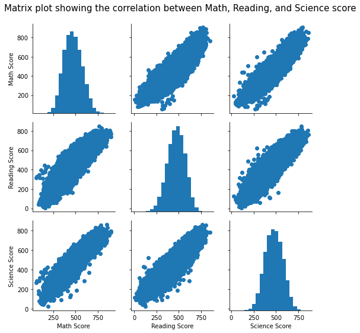

```python
#relationship plot for math, reading and science
dataList = ['Math Score', 'Reading Score', 'Science Score']

g = sb.PairGrid(data = pisa_df, vars= dataList)
g.map_diag(plt.hist, bins = 20)
g.map_offdiag(plt.scatter)
plt.title("Matrix plot showing the correlation between Math, Reading, and Science score",fontsize=15, x=-0.6,y=2.2)

plt.show();
```

- The matrix plot shows the relationship between all scores which are all positive.

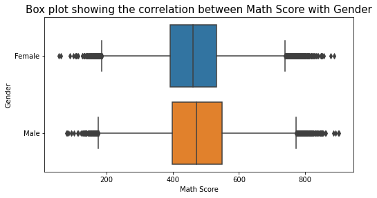

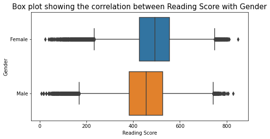

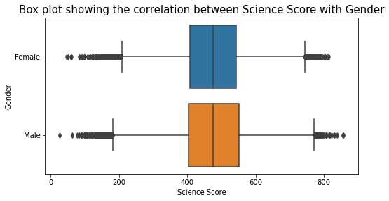

```python
#relationship plot for math, reading and science with gender
dataList = ['Math Score', 'Reading Score', 'Science Score']

c=1
for i in dataList:
    plt.figure(figsize = [8, 14])
    plt.subplot(len(dataList), 1, c )
    sb.boxplot(data=pisa_df, y='Gender', x=i,)
    plt.title('Box plot showing the correlation between '+ i + ' with Gender',fontsize=15)
    c=c+1
```

### Talk about some of the relationships you observed in this part of the investigation. How did the feature(s) of interest vary with other features in the dataset?

> clearly, the relationship between subjects scores is positive.

### Did you observe any interesting relationships between the other features (not the main feature(s) of interest)?

> It can be seen, the relationship between gender and reading score which females had better score than males.

## Multivariate Exploration

> Create plots of three or more variables to investigate your data even further. Make sure that your investigations are justified, and follow from your work in the previous sections.

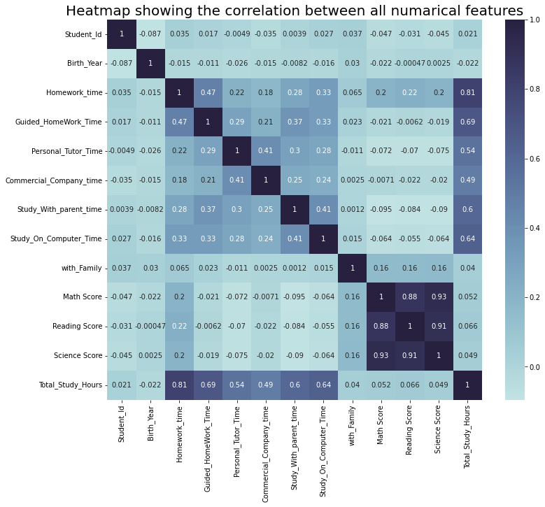

```python
#Heatmap to see relationship between numarical features
plt.figure(figsize=[12,10])
sb.heatmap(pisa_df.corr(),annot=True, cmap=sb.color_palette("ch:start=.2,rot=-.3", as_cmap=True))
plt.title('Heatmap showing the correlation between all numarical features',fontsize=20);
```

- This heatmap displays the correlation between numerical features. Most of the features don't have a strong relationship except the score of subjects.

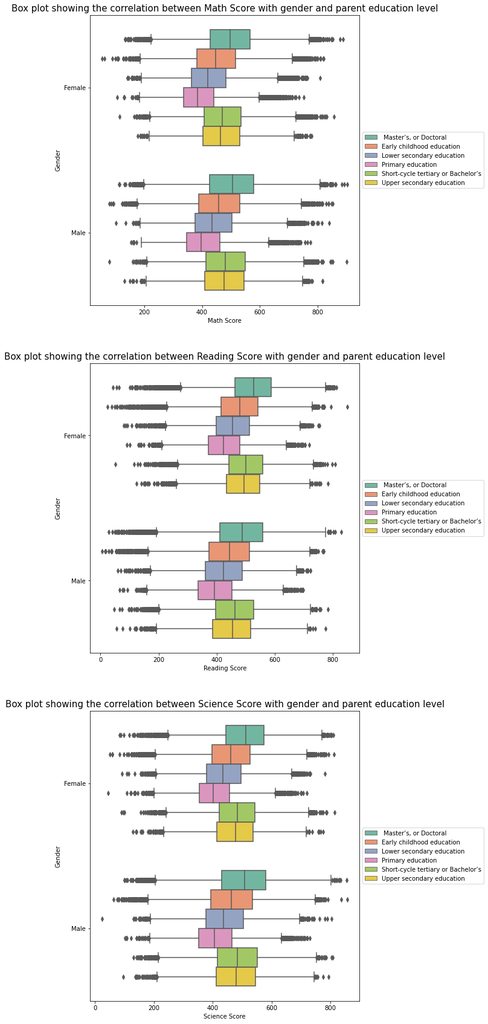

```python
#relationship plot for math, reading and science with gender and parent education level

dataList = ['Math Score', 'Reading Score', 'Science Score']
c=1
plt.figure(figsize = [8, 30])
for i in dataList:
    plt.subplot(len(dataList), 1, c)
    sb.boxplot(data=pisa_df, hue='Parents_Highest_Education',y='Gender' , x=i, palette=sb.color_palette("Set2") )
    plt.title('Box plot showing the correlation between '+ i + ' with gender and parent education level',fontsize=15)
    plt.legend(loc = 6, bbox_to_anchor = (1.0, 0.5))
    c=c+1
```

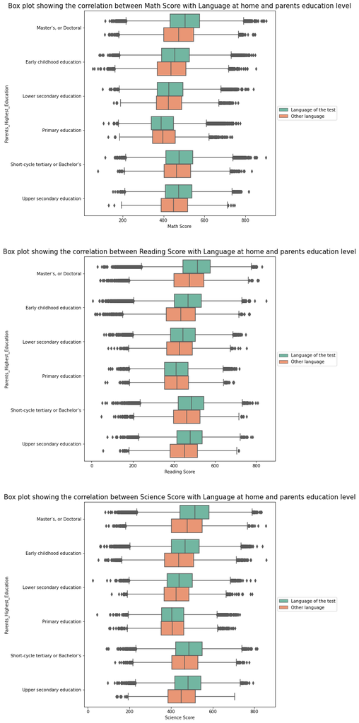

```python
#relationship plot for math, reading and science with Language at home with parent education level

dataList = ['Math Score', 'Reading Score', 'Science Score']
c=1
plt.figure(figsize = [8, 30])
for i in dataList:
    plt.subplot(len(dataList), 1, c)
    sb.boxplot(data=pisa_df, x=i, y='Parents_Highest_Education', hue='Language_at_home', palette=sb.color_palette("Set2") )
    plt.title('Box plot showing the correlation between '+ i + ' with Language at home and parents education level',fontsize=15)
    plt.legend(loc = 6, bbox_to_anchor = (1.0, 0.5))
    c=c+1
```

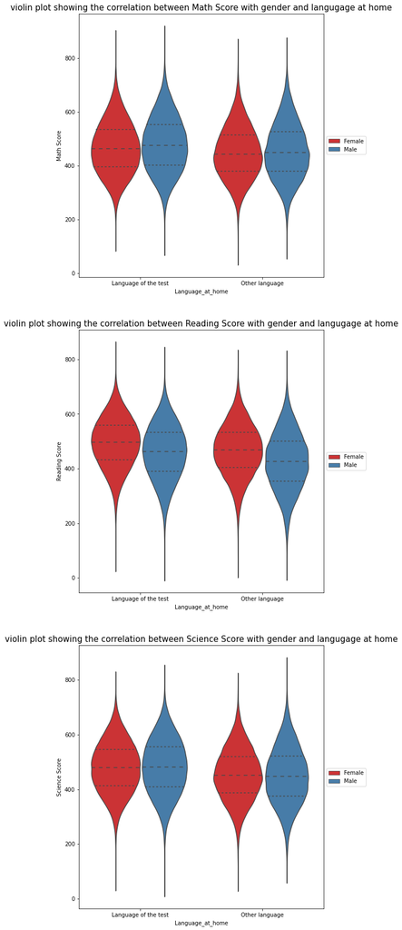

```python
#relationship plot for math, reading and science with gender with parent education level

dataList = ['Math Score', 'Reading Score', 'Science Score']
c=1
plt.figure(figsize = [8, 30])
for i in dataList:
    plt.subplot(len(dataList), 1, c)
    sb.violinplot(data=pisa_df, x='Language_at_home', y=i, hue='Gender', palette=sb.color_palette("Set1"),  inner='quartile' )
    plt.title('violin plot showing the correlation between '+ i + ' with gender and langugage at home',fontsize=15)
    plt.legend(loc = 6, bbox_to_anchor = (1.0, 0.5))
    c=c+1
```

[figure not shown]

```python
#relationship plot for math, reading and science with Language at home with mothers job

dataList = ['Math Score', 'Reading Score', 'Science Score']
c=1
plt.figure(figsize = [8, 30])
for i in dataList:
    plt.subplot(len(dataList), 1, c)
    sb.violinplot(data=pisa_df, x='Language_at_home', y=i, hue='Mother_job', palette=sb.color_palette("Set1"), inner='quartile')
    plt.title('violin plot showing the correlation between '+ i + ' with mothers job and parents education level',fontsize=15)
    plt.legend(loc = 6, bbox_to_anchor = (1.0, 0.5))
    c=c+1
```

[figure not shown]

```python
#relationship plot for math, reading and science with Language at home with fathers job

dataList = ['Math Score', 'Reading Score', 'Science Score']
c=1
plt.figure(figsize = [8, 30])
for i in dataList:
    plt.subplot(len(dataList), 1, c)
    sb.violinplot(data=pisa_df, x='Language_at_home', y=i, hue='Father_job', palette=sb.color_palette("Set1"), inner='quartile')
    plt.title('violin plot showing the correlation between '+ i + ' with Fathers job and parents education level',fontsize=20)
    plt.legend(loc = 6, bbox_to_anchor = (1.0, 0.5))
    c=c+1
```

### Talk about some of the relationships you observed in this part of the investigation. Were there features that strengthened each other in terms of looking at your feature(s) of interest?

> the relationsh between gender and languge at home afeect on reading score which females who talk languge same as test languge has higher score in reading. However, the math and science scores doesn't affect by this feature.

### Were there any interesting or surprising interactions between features?

> The most surprising interactions is between languge at home and job of mother where the scores of all subjects are affected by languge at home and mother job. Also the features of languge at home and father job affect on scores.